# BISI CST2101 Project - Diabetes Analysis(Vivek Anandham_041092466)

## Context

Diabetes is one of the most frequent diseases worldwide and the number of diabetic patients are growing over the years. The main cause of diabetes remains unknown, yet scientists believe that both genetic factors and environmental lifestyle play a major role in diabetes.

A few years ago research was done on a tribe in America which is called the Pima tribe (also known as the Pima Indians). In this tribe, it was found that the ladies are prone to diabetes very early. Several constraints were placed on the selection of these instances from a larger database. In particular, all patients were females at least 21 years old of Pima Indian heritage.

## Objective

Here, we are analyzing different aspects of Diabetes in the Pima tribe by doing Exploratory Data Analysis.

## Data Dictionary

The dataset has the following information:

- Pregnancies: Number of times pregnant
- Glucose: Plasma glucose concentration over 2 hours in an oral glucose tolerance test
- BloodPressure: Diastolic blood pressure (mm Hg)
- SkinThickness: Triceps skin fold thickness (mm)
- Insulin: 2-Hour serum insulin (mu U/ml)
- BMI: Body mass index (weight in kg/(height in m)^2)
- DiabetesPedigreeFunction: A function which scores likelihood of diabetes based on family history.
- Age: Age in years
- Outcome : Class variable (0: person is not diabetic or 1: person is diabetic)

### Q1: Import the necessary libraries and briefly explain the use of each library (1 Mark)

```python
# remove _____ & write the appropriate library name

import numpy as np
import pandas as pd

import seaborn as sns
import matplotlib.pyplot as plt
%matplotlib inline

# You don't have to explain about these libraries below
from sklearn.preprocessing import StandardScaler
from sklearn.linear_model import LogisticRegression
from sklearn.ensemble import RandomForestClassifier

# Handle Warnings
import warnings
warnings.filterwarnings('ignore')
```

#### Write your Answer here:

Ans 1: The following python libraries are key libraries for Data Analysis. Numpy - Basically used for numerical operations & calculations on multidimensional array elements. Pandas - Built on top of Numpy, utilizes Series and DataFrame mainly used for data manipulation and Exploratory Data Analysis. Seaborn, Matplotlib - Primarily used for Data Visualization.Seaborn, built on top of Matplotlib has engaging themes and is relatively easier to use than Matplotlib with simple syntax. On the otherhand, Matplotlib is highly customized and robust with relatively complicated and extensive syntax but highly customizable as per our requirement. %matplotlib inline - line oriented magic function to display the visuals inline below our code snippet in Jupyter Notebook, not in a separate window.

### Q2: Read the given dataset (1 Mark)

```python
#remove _____ & write the appropriate function name

pima = pd.read_csv("diabetes.csv")
```

### Q3. Show the last 5 records of the dataset (1 Mark)

```python
#remove ______ and write the appropriate number in the function

pima.tail()
#Default rows is 5
```

|  | Pregnancies | Glucose | BloodPressure | SkinThickness | Insulin | BMI | DiabetesPedigreeFunction | Age | Outcome |
| --- | --- | --- | --- | --- | --- | --- | --- | --- | --- |
| 995 | 2 | 173 | 79 | 32 | 474 | 35.504233 | 0.402867 | 21 | 1 |
| 996 | 13 | 132 | 70 | 30 | 111 | 35.271769 | 0.168845 | 42 | 1 |
| 997 | 3 | 132 | 87 | 44 | 156 | 34.794755 | 0.765003 | 29 | 1 |
| 998 | 0 | 140 | 0 | 0 | 0 | 41.926693 | 0.209833 | 28 | 1 |
| 999 | 4 | 93 | 59 | 35 | 93 | 45.914499 | 0.737636 | 29 | 1 |

### Q4. Show the first 5 records of the dataset (1 Mark)

```python
#remove _____ & write the appropriate function name and the number of rows to get in the output

pima.head()
#Default rows is 5
```

|  | Pregnancies | Glucose | BloodPressure | SkinThickness | Insulin | BMI | DiabetesPedigreeFunction | Age | Outcome |
| --- | --- | --- | --- | --- | --- | --- | --- | --- | --- |
| 0 | 6 | 148 | 72 | 35 | 0 | 33.6 | 0.627 | 50 | 1 |
| 1 | 1 | 85 | 66 | 29 | 0 | 26.6 | 0.351 | 31 | 0 |
| 2 | 8 | 183 | 64 | 0 | 0 | 23.3 | 0.672 | 32 | 1 |
| 3 | 1 | 89 | 66 | 23 | 94 | 28.1 | 0.167 | 21 | 0 |
| 4 | 0 | 137 | 40 | 35 | 168 | 43.1 | 2.288 | 33 | 1 |

### Q5. Find the dimension of the `pima` dataframe. What do you understand by the dimension of the dataset? (1 Mark)

```python
#remove _____ & write the appropriate function name

pima.shape
```

```
(1000, 9)
```

#### Write your Answer here:

Ans 5: Dimension of a dataset implies the number of rows and columns present. Here in our case our imported DataFrame has 1000 records and 9 features.

### Q6. Find the size of the `pima` dataframe. (1 Mark)

```python
#remove _____ & write the appropriate function name

pima.size
```

```
9000
```

#### Write your Answer here:

Ans 6: Size returns the number of elements in our DataFrame object ie.., number of row times number of columns(1000*9 = 9000)

### Q7. Display the data types of all the variables in the data set? (1 Mark)

```python
#remove _____ & write the appropriate function name

pima.dtypes
```

```
Pregnancies                   int64
Glucose                       int64
BloodPressure                 int64
SkinThickness                 int64
Insulin                       int64
BMI                         float64
DiabetesPedigreeFunction    float64
Age                           int64
Outcome                       int64
dtype: object
```

### Q8. Are there any missing values in the `pima` dataframe? Which variables have missing values? (1 Mark)

```python
#remove _____ & write the appropriate function name

pima.isnull().values.any()
```

```
False
```

#### Write your Answer here:

Ans 8: pima.isnull() - checks for the presense of missing, NaN values in our pima DataFrame and any() over here consolidates for a final boolean value for our entire df.

### Q9. Find the summary statistics for all variables except for `'Outcome'` variable? Choose any one column/variable and explain all the statistical measures. (2 Marks)

```python
#remove _____ & write the appropriate function name

pima.iloc[:,0:8].describe() # Statistical Summary for all features except Outcome
```

|  | Pregnancies | Glucose | BloodPressure | SkinThickness | Insulin | BMI | DiabetesPedigreeFunction | Age |
| --- | --- | --- | --- | --- | --- | --- | --- | --- |
| count | 1000.000000 | 1000.00000 | 1000.000000 | 1000.000000 | 1000.000000 | 1000.000000 | 1000.000000 | 1000.000000 |
| mean | 4.051000 | 125.21600 | 69.072000 | 20.755000 | 83.086000 | 32.664772 | 0.494090 | 33.830000 |
| std | 3.325576 | 32.27772 | 20.465328 | 16.008599 | 117.255326 | 7.563614 | 0.322158 | 11.268189 |
| min | 0.000000 | 0.00000 | 0.000000 | 0.000000 | 0.000000 | 0.000000 | 0.078000 | 21.000000 |
| 25% | 1.000000 | 102.00000 | 64.000000 | 0.000000 | 0.000000 | 28.275000 | 0.258750 | 25.000000 |
| 50% | 3.000000 | 122.00000 | 72.000000 | 24.000000 | 23.000000 | 32.800000 | 0.408500 | 30.000000 |
| 75% | 6.000000 | 146.00000 | 80.000000 | 33.000000 | 133.500000 | 36.900000 | 0.658500 | 41.000000 |
| max | 17.000000 | 199.00000 | 122.000000 | 99.000000 | 846.000000 | 67.100000 | 2.420000 | 81.000000 |

```python
pima['Pregnancies'].describe() # Statistical Summary for Pregnancies feature
#pima.iloc[:,1].describe()
#pima.loc[:,'Pregnancies'].describe()
```

```
count    1000.000000
mean        4.051000
std         3.325576
min         0.000000
25%         1.000000
50%         3.000000
75%         6.000000
max        17.000000
Name: Pregnancies, dtype: float64
```

#### Write your Answer here:

Ans 9:iloc is an integer position based indexing method to access elements. Here we provide '0:8' as range to exclude our last 'Outcome' variable in our statistical analysis. Similarly we can use loc and direct accessing of the df elements too. Describe method provides a basic descriptive statistics about the data(Count, Mean, Standard Deviation,Median etc.., If in case Object type then freq, unique and top are included). For object types we must use 'include' parameter to include them too in the statistical summary.

### Q10. Plot the distribution plot for the variable `'BloodPressure'`. Write your observations from the plot. (2 Marks)

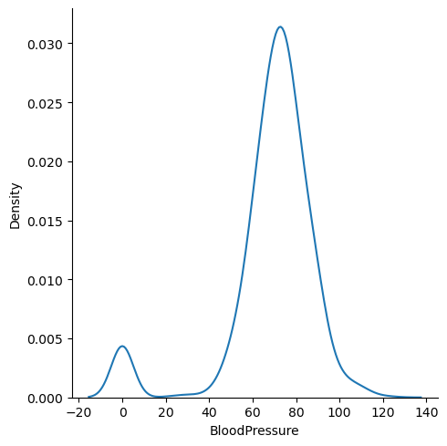

```python
#remove _____ & write the appropriate library name

sns.displot(pima['BloodPressure'], kind='kde')
plt.show()
```

#### Write your Answer here:

Ans 10: Distribution plot for 'BloodPressure' feature using seaborn library which depicts the distribution of values for the variable. kind = kde provides the Kernel Density Estimate plot. Similarly we can also provide 'hist' as a value for plotting as a histogram.

### Q11. What is the `'BMI'` for the person having the highest `'Glucose'`? (1 Mark)

```python
#remove _____ & write the appropriate function name

pima[pima['Glucose']==pima['Glucose'].max()]['BMI']
```

```
661    42.9
Name: BMI, dtype: float64
```

```python
pima.iloc[661]
```

```
Pregnancies                   1.000
Glucose                     199.000
BloodPressure                76.000
SkinThickness                43.000
Insulin                       0.000
BMI                          42.900
DiabetesPedigreeFunction      1.394
Age                          22.000
Outcome                       1.000
Name: 661, dtype: float64
```

#### Write your Answer here:

Ans 11:.max() is used to retrieve the maximum value for a numeric feature. And the BMI for the person with highest glucose is 42.9

### Q12.

#### 12.1 What is the mean of the variable `'BMI'`?

#### 12.2 What is the median of the variable `'BMI'`?

#### 12.3 What is the mode of the variable `'BMI'`?

#### 12.4 Are the three measures of central tendency equal?

### (2 Marks)

```python
#remove _____ & write the appropriate function name

m1 = pima['BMI'].mean()  #Mean
print(m1)
m2 = pima['BMI'].median()  #Median
print(m2)
m3 = pima['BMI'].mode()[0]  #Mode
print(m3)
```

```
32.664772391408796
32.8
32.0
```

#### Write your Answer here:

Ans 12: mean() - provides the average value for the chosen BMI numeric feature median() - provides the mid-point(50%) value for the chosen BMI numeric feature mode() - provides the most common repeated value for the chosen BMI numeric feature Here, the measures of central tendency are quite approximately equal. Median is slightly greater than Mean which implies, the distribution might be slightly left skewed but very close to normal symmetrical ie.., approximately 68% of data falls between the first quartile(Mean +- 1(SD)). Also most repeated value is 32.0 which is on the left side(less than) of the median.

### Q13. How many women's `'Glucose'` level is above the mean level of `'Glucose'`? (1 Mark)

```python
#remove _____ & write the appropriate function name

pima[pima['Glucose']>pima['Glucose'].mean()].shape[0]
```

```
449
```

### Q14. Create the pairplot for variables `'Glucose'`, `'SkinThickness'` and `'DiabetesPedigreeFunction'`. Write you observations from the plot. (2 Marks)

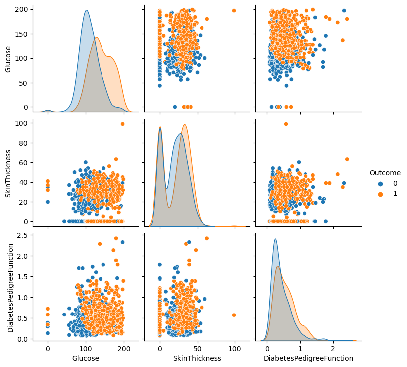

```python
#remove _____ & write the appropriate function and argument names

sns.pairplot(data=pima, vars=['Glucose', 'SkinThickness', 'DiabetesPedigreeFunction'], hue='Outcome')
plt.show()
```

### Q15. Plot the scatterplot between `'Glucose'` and `'Insulin'`. Write your observations from the plot. (1 Mark)

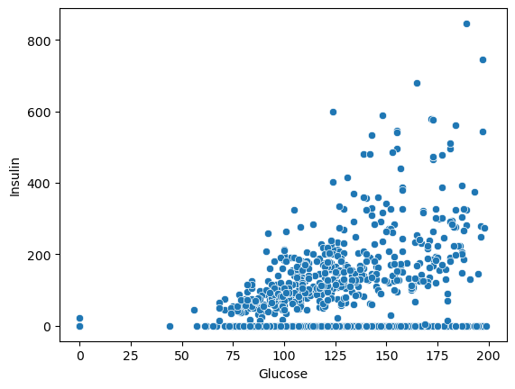

```python
#remove _____ & write the appropriate function name

sns.scatterplot(x='Glucose',y='Insulin',data=pima)
plt.show()
```

#### Write your Answer here:

Ans 15: This plots a scatter plot between the two continuous values(Glucose and Insulin). From the above plot we can say like Women having a normal Glucose level(less than 155 mg/dL) has a significantly low or normal insulin level too(less than 166 mIU/L) which might contribute to Outcome 0 most probably and the higher Glucose and Insulin might contribute for Diabtes existence(Outcome 1)

### Q16. Plot the boxplot for the 'Age' variable. Are there outliers? (1 Mark)

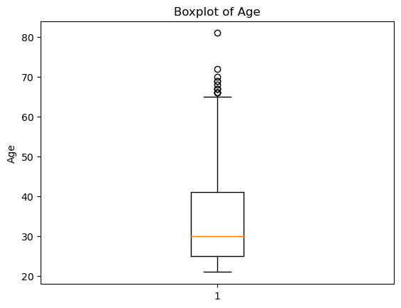

```python
#remove _____ & write the appropriate function and column name

plt.boxplot(pima['Age'])

plt.title('Boxplot of Age')
plt.ylabel('Age')
plt.show()
```

#### Write your Answer here:

Ans 16: This plots a box plot for the Age variable where there are significant outliers above the Age 65 in the distribution(>Q3+1.5(IQR))

### Q17. Find and visualize the the correlation matrix. Write your observations from the plot. (1 Mark)

```python
#remove _____ & write the appropriate function name and run the code

corr_matrix = pima.iloc[:,0:8].corr()

corr_matrix
```

|  | Pregnancies | Glucose | BloodPressure | SkinThickness | Insulin | BMI | DiabetesPedigreeFunction | Age |
| --- | --- | --- | --- | --- | --- | --- | --- | --- |
| Pregnancies | 1.000000 | 0.112930 | 0.127463 | -0.080033 | -0.064909 | 0.012920 | -0.025452 | 0.548665 |
| Glucose | 0.112930 | 1.000000 | 0.134993 | 0.050656 | 0.334175 | 0.222138 | 0.127004 | 0.255567 |
| BloodPressure | 0.127463 | 0.134993 | 1.000000 | 0.249063 | 0.117369 | 0.247275 | 0.059303 | 0.240416 |
| SkinThickness | -0.080033 | 0.050656 | 0.249063 | 1.000000 | 0.472663 | 0.387055 | 0.214026 | -0.121236 |
| Insulin | -0.064909 | 0.334175 | 0.117369 | 0.472663 | 1.000000 | 0.198281 | 0.180284 | -0.039887 |
| BMI | 0.012920 | 0.222138 | 0.247275 | 0.387055 | 0.198281 | 1.000000 | 0.163270 | 0.023921 |
| DiabetesPedigreeFunction | -0.025452 | 0.127004 | 0.059303 | 0.214026 | 0.180284 | 0.163270 | 1.000000 | 0.006809 |
| Age | 0.548665 | 0.255567 | 0.240416 | -0.121236 | -0.039887 | 0.023921 | 0.006809 | 1.000000 |

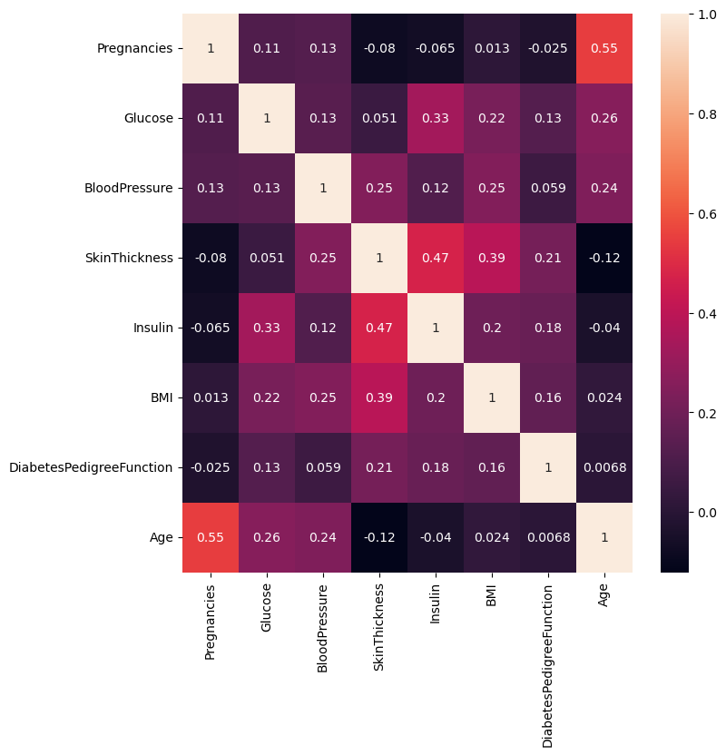

```python
#remove _____ & write the appropriate function name

plt.figure(figsize=(8,8))
sns.heatmap(corr_matrix, annot = True)

# display the plot
plt.show()
```

#### Write your Answer here:

Ans 17: Seaborn heatmap is used to visualize the correlation matrix here between the predictor features(-1 to +1). Here Age-Pregnancy,Glucose-Insulin, SkinThickness-Insulin and SkinThickness-BMI have slightly good +ve correlation(linear dependency) while Age and SkinThickness, Pregnancy-Insulin have a -ve correlation(inversely correlated)

## Model Training

### Q18. Split and scale the data (2 Mark)

```python
# Split the data into dependent and independent variables
# remove _____ & write the appropriate function variable name
y = pima.Outcome
x = pima.drop('Outcome', axis = 1)
```

```python
# Using StandarScaler scale the data
# remove _____ & write the appropriate function function name

from sklearn.preprocessing import StandardScaler
scaler = StandardScaler()
X = scaler.fit_transform(x)
```

```python
# Splitting the data into train and test. Use test size as 15%
# remove _____ & complete the code

from sklearn.model_selection import train_test_split
x_train, x_test, y_train, y_test = train_test_split(X, y, test_size = 0.15, stratify=y,  random_state = 45)
```

### Q19. Train a Logistic Regression Model. What is the Accuracy and how many True Positives and True Negatives did you get? (3 Marks)

```
Accuracy of Logistic Regression model on the train set: 0.76
Accuracy of the Logictic Regression model on the test set: 0.75
```

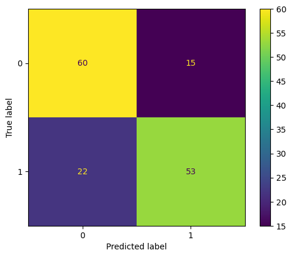

```python
# remove _____ & complete the code

# import the model
from sklearn.linear_model import LogisticRegression

# Instantiate the model
lr = LogisticRegression(random_state=123)

# fit the model on the train set
m = lr.fit(x_train, y_train)

# Predict on x_test
y_pred = m.predict(x_test)

# Evaluate the model
print('Accuracy of Logistic Regression model on the train set: {:.2f}'.format(m.score(x_train, y_train)))
print('Accuracy of the Logictic Regression model on the test set: {:.2f}'.format(m.score(x_test, y_test)))

from sklearn.metrics import confusion_matrix,ConfusionMatrixDisplay
lrconf=confusion_matrix(y_test, y_pred)
disp = ConfusionMatrixDisplay(confusion_matrix=lrconf,display_labels=lr.classes_)
disp.plot()
plt.show()
```

#### Write your Answer here:

Ans 19: Model Accuracy on Training Set is **76%** which implies no overfitting while on Test Set is **75%**. With the help of sklearn.metrics Confusion matrix is plotted from which True Positives are **53** and True Negatives are **60**.And FP:15,FN:22 respectively. Here we need to try to reduce down the False Positives and Negatives as they are quite high considering its a medical domain analysis. We can try to check with other classification algorithms for accuracy, use features of high correlation only, handle outliers first and handle features imbalance too. Here the decision 'Outcome' is balanced with 50:50 we can check for other features too.

```python
pima.Outcome.value_counts(normalize=True)*100
```

```
1    50.0
0    50.0
Name: Outcome, dtype: float64
```

### Q20. Train a Random Forest Model. What is the Accuracy and how many True Positives and True Negatives did you get? (3 Marks)

```
Accuracy of Random Forest model on the train set: 0.82
Accuracy of Random Forest model on the test set: 0.77
```

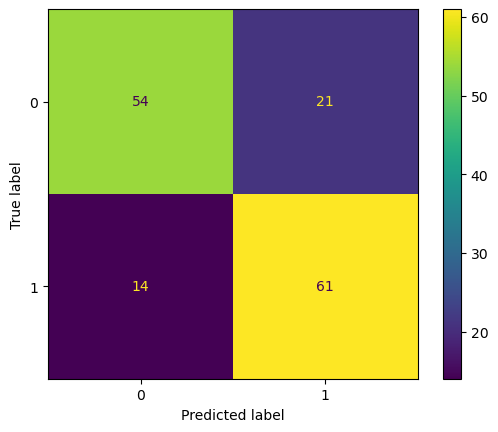

```python
#remove _____ & complete the code

# Import the Model
from sklearn.ensemble import RandomForestClassifier

# Instantiate the model.
rf = RandomForestClassifier(n_estimators=301, max_depth=3,random_state=123)

# fit the model on the train set
m2 = rf.fit(x_train, y_train)

# Predict on x_test
y_pred2 = m2.predict(x_test)

# Evaluate the Model
print('Accuracy of Random Forest model on the train set: {:.2f}'.format(m2.score(x_train, y_train)))
print('Accuracy of Random Forest model on the test set: {:.2f}'.format(m2.score(x_test, y_test)))
rfconf=confusion_matrix(y_test, y_pred2)
disp = ConfusionMatrixDisplay(confusion_matrix=rfconf,display_labels=rf.classes_)
disp.plot()
plt.show()
```

#### Write your Answer here:

Ans 20: Now Trying out RandomForest(ensemble) next with 301 estimators(trees) with a max depth value as 3, the Model Accuracy on Training Set is **82%** while on Test Set is **77%**. With the help of sklearn.metrics Confusion matrix is plotted from which True Positives are **61** and True Negatives are **54**.And FP:21,FN:14 respectively. Here True Positives is increased than LR while True Negatives is decreased. Also, false negatives are decreased which is good but false positives is increased.Accuracy is increased to **77%** which is considerable. Still we need to try to reduce down the False Positives and Negatives as they are quite high considering its a medical domain analysis. However still We can try to check with other classification algorithms for accuracy, use features of high correlation only, handle outliers and handle features imbalance too.